# Imbalanced Classification using Borderline-SMOTE and CURE-SMOTE

# About Me

## Wessam Abo Zayed

**Automation Engineering · PLC Programming · Data Analyst**

- Computer Scientist with a focus on Automation Engineering, PLC Programming, and Data Analytics. I combine technical expertise with analytical problem-solving skills to develop practical and efficient solutions for industrial automation systems and data-driven applications.

## Kontakt

| Plattform | Link |
| --- | --- |
| **E-Mail** | abozayed.wessam@gmail.com |
| **LinkedIn** | [linkedin.com/in/wessam-abozayed](https://www.linkedin.com/in/wessam-abozayed/) |
| **GitHub** | github.com/wessam-abo-zayed |
| **Tableau Public** | public.tableau.com/app/profile/wessam3726 |

## General View:

[figure not shown]

### Machine Learning

- Machine learning (ML) is a discipline of artificial intelligence (AI) that provides machines with the ability to automatically learn from data and past experiences while identifying patterns to make predictions with minimal human intervention.
- Machine learning methods enable computers to operate autonomously without explicit programming. ML applications are fed with new data, and they can independently learn, grow, develop, and adapt.
- Machine learning derives insightful information from large volumes of data by leveraging algorithms to identify patterns and learn in an iterative process. ML algorithms use computation methods to learn directly from data instead of relying on any predetermined equation that may serve as a model.

### How does machine learning work?

- Machine learning algorithms are molded on a training dataset to create a model.  
  As new input data is introduced to the trained ML algorithm, it uses the developed model to make a prediction.

[figure not shown]

### Types of Machine Learning:

- machine learning is categorized into four main types:

[figure not shown]

### 1. Supervised learning:

- Classification: The data should hase input "features" and output "Label", and the label should be categorized (yes or no, true or false, male or female, etc...), Example: email spam detection.
- Regression: The data should have features and continuous output, where input and output variables have a linear relationship. Examples: weather prediction.

### 2. UnSupervised learning:

- The data here hase features but there is no output, becase the algorithm will buold the output depends grouping the similarity between the data rows and this way called "Clustering".

### 3. Semi-supervised learning:

- Semi-supervised learning comprises characteristics of both supervised and unsupervised machine learning. It uses the combination of labeled and unlabeled datasets to train its algorithms. Using both types of datasets, semi-supervised learning overcomes the drawbacks of the options mentioned above, as a college student: the student revising the concept after learning under the direction of a teacher in college is a semi-supervised form of learning)

### 3. Reinforcement learning:

```
- Is a feedback-based process,  the AI component automatically takes stock of its surroundings by the hit & trial method, takes action, learns from experiences, and improves performance. The component is rewarded for each good action and penalized for every wrong move. Thus, the reinforcement learning component aims to maximize the rewards by performing good actions.
```

[figure not shown]

- ### What we want to focus on in this article is imbalanced data analysis in the classification type.

### Classification:

- - Classification is one of the primary uses of data science and machine learning. It is a systematic grouping of observations into categories. Examples could include when scientists categorize plants and animals into different taxonomies.
  - We can understand simply by email filtering classifier:

[figure not shown]

  - The input is a set of data called features, and the output is the Label if the these features "The Class".
    - **Before we enter the data into the model, we have to clean, analyse and process and the data and make it suitable for the specific model.**
    - So, what we are discussing in this article is a specific point of process the data before enter it to the model, and the point is to solve imbalanced data problem.

### Introduction to Imbalanced Data Sets:

- - Data sets are said to be balanced if there are, approximately, as many positive examples of the concept as there are negative ones.
  - The positive examples are more interesting or their misclassification has a higher associate cost.
  - The problem with class imbalances is that standard learners are often biased towards the majority class.

[figure not shown]

- ### How can we evaluate an algorithm in imbalanced domains?
  - Confusion matrix for a two-class problem:

[figure not shown]

  - **Note:** the last evaluation way doesn't take into account False Negative Rate, which is very important in imbalanced problems.
- ### So that we can use AUC way:

[figure not shown]

  AUC: It's the area under ROC curve. (Scalar quantity widely used for estimating classifiers performance).

## STOME

- Synthetic Minority Oversampling Technique (SMOTE) is a well-known oversampling technique for imbalanced data classification problems at the data preprocessing step.
- This method is motivated by a successful technique in handwritten character recognition that creates the extra training data by performing specific operations, such as rotating handwritten characters.
- Frstly selects a minority instance randomly and finds the k-nearest neighbors of that instance. A synthetic instance is then created at a randomly selected point on the line connecting the instance and one random instance among the k neighbors in the feature space.
- ### How does SMOTE work ?
  - The minority class is over-sampled by taking each minority class sample and introducing synthetic examples along the line segments joining any/all of the k minority class nearest neighbors.
  - Synthetic samples are generated in the following way: Take the diﬀerence between the feature vector (sample) under consideration and its nearest neighbor. Multiply this diﬀerence by a random number between 0 and 1, and add it to the feature vector under consideration. This causes the selection of a random point along the line segment between two speciﬁc features. This approach eﬀectively forces the decision region of the minority class to become more general.
  - For a minority instance, the number of randomly chosen neighbors among its k-nearest neighbors depends on the amount of oversampling instances required. For example, with k = 5, if the needed amount is three times the size of the original data, three neighbors out of five nearest neighbors will be chosen, and one synthetic instance is generated on each line connecting the minority instance and the selected neighbors. The following steps can be used to create a synthetic instance:
    - Pick an instance from the minority class randomly.
    - Find the k-nearest neighbors of the current instance.
    - Take the difierence between the current instance and one of the neighbors, then multiply the difierence by a random number gap between 0 and 1.
    - Add the result from the previous step to the current instance and create a new synthetic instance.
  - visualizes how SMOTE works, where only a part of the simulated instances is plotted. This figure shows that xi is one of the selected instances from the minority class and connected to its five nearest neighbors by lines. After a neighbor xneighbor is randomly selected, the synthetic instance xsynth is generated along the line joining xi and xneighbor.

[figure not shown]

- A SMOTE instance has the same expected value as that of a minority instance, a SMOTE instance has a smaller variance than that of a minority instance:

[figure not shown]

## Borderline-SMOTE

- In the training process, Borderline-SMOTE algorithms attempt to learn the borderline of each class, where these borderline instances and the ones nearby are more likely to be misclassified than the ones far from the borderline. In Borderline-SMOTE, all instances in the minority class are divided into three groups: NOISE, DANGER, and SAFE:
  - **NOISE:** instances are rare, probably incorrect, located in areas occupied by the majority class instances.
  - **DANGER:** instances are placed in the area near class boundaries and typically overlap with majority instances.
  - **SAFE:** instances are relatively easier to recognize, and they are the main representatives of the minority class.

[figure not shown]

- After all instances of the minority class are categorized, synthetic instances are then created along the line between DANGER instances and their nearest neighbors. Below is the detailed Borderline-SMOTE1 algorithm and the definitions of the three groups. Supposing the training set is T, the minority class is P, and the majority class is N, we write the two classes of instances as:

[figure not shown]

  where pnum and nnum are the numbers of minority and majority instances, respectively.
- Real example of Borderline stome:

[figure not shown]

## CURE-SMOTE

- the problem of classifying imbalanced data has attracted increasing attention. Imbalanced data sets generally refer to data that is distributed unevenly among different categories where the data in the smaller category is far less prevalent than data in the larger category. The Imbalance Ratio (IR) is defined as the ratio of the number of minor class samples to the number of major class samples. Therefore, imbalanced data causes the training set for each decision tree to be imbalanced during the first “random” procedure. The classification performance of traditional RF on imbalanced data sets is even worse than that of SVMs
- The general idea of the CURE-SMOTE algorithm is as follows: cluster the samples of the minor class using CURE, remove the noise and outliers from the original samples, and, then, generate artificial samples randomly between representative points and the centre point. The implementation steps of the CURE-SMOTE algorithm are as follows:
  - 1- Normalize the dataset, extract the minor class samples, X, and calculate the distance dist among them. Each point is initially considered as a cluster. For each cluster U, Ur and Uc represent the representative set and the centre point, respectively. For two data items p and q, the distance between the two clusters U and V is:

[figure not shown]

  - 2- Determine the clustering number "c" and update the centre and representative points after clustering and merging based on the smallest distance of the two clusters,

[figure not shown]

    |U| is the number of data items for class U.  
    α is generally 0.5.
  - 3- Generate a new sample according to the interpolation formula. (X: samples after clustering by the CURE algorithm).

[figure not shown]

  - 4- Calculate IR, and return to "3" if IR ≤ IR0.
  - 5- Finally, classify the new dataset and add samples of the major class by RF, Classifing new dataset as the following:

[figure not shown]

- During the clustering process of the CURE-SMOTE algorithm, noisy points must be removed because they are far away from the normal points, and they hinder the merge speed in the corresponding class.
- When clustering is complete, the clusters containing only a few samples are also deemed to be noisy points. For the sample points after clustering, the interpolation can effectively prevent generalization and preserve the original distribution attributes of the data set.
- In the interpolation formula, Xi is replaced by the representative points; consequently, the samples are generated only between the representative samples and the samples in the original minor class, which effectively avoids the influence of boundary points.
- The combination of the clustering and merge operations serves to eliminate the noise points at the end of the process and reduce the complexity because there is no need to eliminate the farthest generated artificial samples after the SMOTE algorithm runs. Moreover, all the termination criteria such as reaching the pre-set number of clusters, the number of representative samples, or the distance threshold, avoid setting the k value of the original SMOTE algorithm and, thus, reduce the instability of the proposed algorithm.

### CURE-SMOTE algorithm diagram:

[figure not shown]

### Python Implimintation:

(Credit Card Fraud Detection)

```python
import numpy as np
import pandas as pd
import seaborn as sns
import matplotlib.pyplot as plt
from time import time
from collections import Counter
from imblearn.over_sampling import SMOTE
from sklearn import metrics
```

```python
df = pd.read_csv('Credit Card Fraud Detection/creditcard.csv')
df.head(3)
```

|  | Time | V1 | V2 | V3 | V4 | V5 | V6 | V7 | V8 | V9 | ... | V21 | V22 | V23 | V24 | V25 | V26 | V27 | V28 | Amount | Class |
| --- | --- | --- | --- | --- | --- | --- | --- | --- | --- | --- | --- | --- | --- | --- | --- | --- | --- | --- | --- | --- | --- |
| 0 | 0.0 | -1.359807 | -0.072781 | 2.536347 | 1.378155 | -0.338321 | 0.462388 | 0.239599 | 0.098698 | 0.363787 | ... | -0.018307 | 0.277838 | -0.110474 | 0.066928 | 0.128539 | -0.189115 | 0.133558 | -0.021053 | 149.62 | 0 |
| 1 | 0.0 | 1.191857 | 0.266151 | 0.166480 | 0.448154 | 0.060018 | -0.082361 | -0.078803 | 0.085102 | -0.255425 | ... | -0.225775 | -0.638672 | 0.101288 | -0.339846 | 0.167170 | 0.125895 | -0.008983 | 0.014724 | 2.69 | 0 |
| 2 | 1.0 | -1.358354 | -1.340163 | 1.773209 | 0.379780 | -0.503198 | 1.800499 | 0.791461 | 0.247676 | -1.514654 | ... | 0.247998 | 0.771679 | 0.909412 | -0.689281 | -0.327642 | -0.139097 | -0.055353 | -0.059752 | 378.66 | 0 |

3 rows × 31 columns

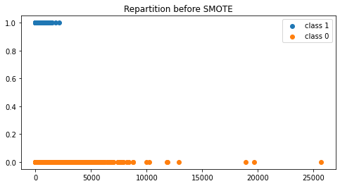

```python
plt.figure(figsize=(8, 4))
plt.title('Repartition before SMOTE')
plt.scatter(df[df["Class"]==1]["Amount"], df[df["Class"]==1]["Class"], label='class 1')
plt.scatter(df[df["Class"]==0]["Amount"], df[df["Class"]==0]["Class"], label='class 0')
plt.legend()
plt.grid(False)
plt.show()
```

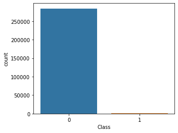

```python
plt.figure(figsize = (5, 4))
sns.countplot(df['Class'])
plt.show()
```

```python
y = df["Class"]
X = df.loc[:,df.columns!="label"]
```

```python
smt = SMOTE()
X_smote, y_smote = smt.fit_resample(X, y)
```

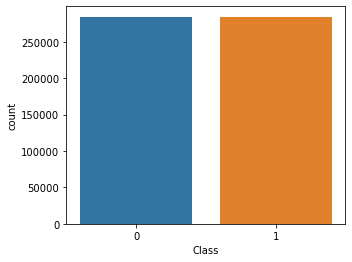

```python
plt.figure(figsize = (5, 4))
sns.countplot(y_smote)
plt.show()
```

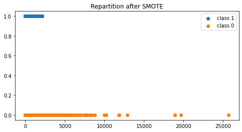

```python
plt.figure(figsize=(8, 4))
plt.title('Repartition after SMOTE')
plt.scatter(X_smote[y_smote==1]["Amount"], X_smote[y_smote==1]["Class"], label='class 1')
plt.scatter(X_smote[y_smote==0]["Amount"], X_smote[y_smote==0]["Class"], label='class 0')
plt.legend()
plt.grid(False)
plt.show()
```

```python
print("Count two Classes after smote:    ",Counter(y_smote))
```

```
Count two Classes after smote:     Counter({0: 284315, 1: 284315})
```

```python
# Splitting arrays or matrices into random train and test subsets
from sklearn.model_selection import train_test_split
# i.e. 70 % training dataset and 30 % test datasets
X_train, X_test, y_train, y_test = train_test_split(X_smote, y_smote, test_size = 0.30)
```

```python
# creating a RF classifier
clf = RandomForestClassifier(n_estimators = 100)
# fit function is used to train the model using the training sets as parameters
clf.fit(X_train, y_train)
# performing predictions on the test dataset
y_pred = clf.predict(X_test)
# metrics are used to find accuracy or error
print()
print("ACCURACY OF THE MODEL: ", metrics.accuracy_score(y_test, y_pred))
```

```
ACCURACY OF THE MODEL:  1.0
```

### Python Implimintation:

(Mammography dataset)

```python
from imblearn.datasets import fetch_datasets
df1 = fetch_datasets()["mammography"]
X, y = df1.data, df1.target
```

```python
y
```

```
array([-1, -1, -1, ...,  1,  1,  1], dtype=int64)
```

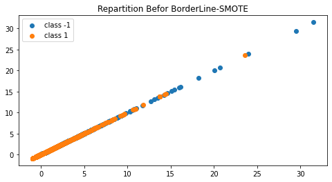

```python
plt.figure(figsize=(8, 4))
plt.title('Repartition Befor BorderLine-SMOTE')
plt.scatter(X[y==-1], X[y==-1], label='class -1')
plt.scatter(X[y==1], X[y==1], label='class 1')
plt.legend()
plt.grid(False)
plt.show()
```

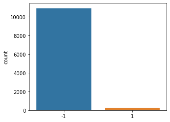

```python
plt.figure(figsize = (5, 4))
sns.countplot(y)
plt.show()
```

```python
from collections import Counter
from imblearn.over_sampling import BorderlineSMOTE
smt = BorderlineSMOTE(random_state=42)
X_res, y_res = smt.fit_resample(X, y)
```

```python
print('Resampled dataset shape %s' % Counter(y_res))
```

```
Resampled dataset shape Counter({-1: 10923, 1: 10923})
```

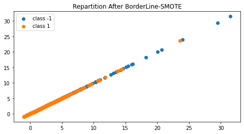

```python
plt.figure(figsize=(8, 4))
plt.title('Repartition After BorderLine-SMOTE')
plt.scatter(X_res[y_res==-1], X_res[y_res==-1], label='class -1')
plt.scatter(X_res[y_res==1], X_res[y_res==1], label='class 1')
plt.legend()
plt.grid(False)
plt.show()
```

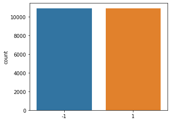

```python
plt.figure(figsize = (5, 4))
sns.countplot(y_res)
plt.show()
```

```python
from sklearn.model_selection import train_test_split
X_train, X_test, y_train, y_test = train_test_split(X_res, y_res, stratify=y_res, random_state=0)
```

```python
from sklearn.neighbors import KNeighborsClassifier
knn = KNeighborsClassifier(n_neighbors=30)
knn.fit(X_train, y_train)
y_pred_knn = knn.predict(X_test)

# Predict on dataset which model has not seen before
print(knn.predict(X_test))
```

```
[ 1 -1  1 ...  1  1  1]
```

```python
# Calculate the accuracy of the model
print(knn.score(X_test, y_test))
```

```
0.9741852801171732
```

```python
print()
print("ACCURACY OF THE MODEL KNN: ", metrics.accuracy_score(y_test, y_pred_knn))
```

```
ACCURACY OF THE MODEL KNN:  0.9741852801171732
```

- https://www.spiceworks.com/tech/artificial-intelligence/articles/what-is-ml/
- https://imbalanced-learn.org/stable/references/generated/imblearn.over_sampling.BorderlineSMOTE.html
- https://imbalanced-learn.org/stable/auto_examples/ensemble/plot_comparison_ensemble_classifier.html#sphx-glr-auto-examples-ensemble-plot-comparison-ensemble-classifier-py
- https://www.geeksforgeeks.org/k-nearest-neighbor-algorithm-in-python/
- https://arxiv.org/pdf/1106.1813.pdf
- https://www.hindawi.com/journals/complexity/2021/6675279/